# fh Data

This model attempts to forecast the finance hires. The trend and cycle in our data is severely dominated by the business cycle which is rather stochastic. Hence we opt against fitting it against an arbitrary deterministic trend, be it polynomial or periodic, and we use an ARIMA model to fit the trend and cycle instead. Let’s see auto.arima’s choice based on different information criteria, using a large maximum order. We enforce the usage of seasonal dummies.

```r
auto.arima(fh,seasonal=F,xreg=seasonaldummy(fh),ic='bic',max.p=12,
  max.q=12,max.P=5,max.Q=5,max.order = 24)
```

```
## Series: fh
## Regression with ARIMA(1,1,1) errors
##
## Coefficients:
##           ar1      ma1       Jan      Feb       Mar      Apr      May      Jun
##       -0.1638  -0.5562  -24.2236  43.8219  -11.4935  -1.1898  38.0992  39.0219
## s.e.   0.0993   0.0839    4.1778   4.0803    4.2504   4.3285   4.3807   4.3981
##          Jul      Aug      Sep      Oct      Nov
##       46.523  43.7628  21.6768  14.1258  38.4074
## s.e.   4.383   4.3331   4.2581   4.0873   4.2490
##
## sigma^2 estimated as 243.2:  log likelihood=-947.6
## AIC=1923.21   AICc=1925.17   BIC=1971.28
```

```r
auto.arima(fh,seasonal=F,xreg=seasonaldummy(fh),ic='aic',max.p=12,
  max.q=12,max.P=5,max.Q=5,max.order = 24)
```

```
## Series: fh
## Regression with ARIMA(1,1,1) errors
##
## Coefficients:
##           ar1      ma1       Jan      Feb       Mar      Apr      May      Jun
##       -0.1638  -0.5562  -24.2236  43.8219  -11.4935  -1.1898  38.0992  39.0219
## s.e.   0.0993   0.0839    4.1778   4.0803    4.2504   4.3285   4.3807   4.3981
##          Jul      Aug      Sep      Oct      Nov
##       46.523  43.7628  21.6768  14.1258  38.4074
## s.e.   4.383   4.3331   4.2581   4.0873   4.2490
##
## sigma^2 estimated as 243.2:  log likelihood=-947.6
## AIC=1923.21   AICc=1925.17   BIC=1971.28
```

```r
auto.arima(fh,seasonal=F,xreg=seasonaldummy(fh),ic='aicc',max.p=12,
  max.q=12,max.P=5,max.Q=5,max.order = 24)
```

```
## Series: fh
## Regression with ARIMA(1,1,1) errors
##
## Coefficients:
##           ar1      ma1       Jan      Feb       Mar      Apr      May      Jun
##       -0.1638  -0.5562  -24.2236  43.8219  -11.4935  -1.1898  38.0992  39.0219
## s.e.   0.0993   0.0839    4.1778   4.0803    4.2504   4.3285   4.3807   4.3981
##          Jul      Aug      Sep      Oct      Nov
##       46.523  43.7628  21.6768  14.1258  38.4074
## s.e.   4.383   4.3331   4.2581   4.0873   4.2490
##
## sigma^2 estimated as 243.2:  log likelihood=-947.6
## AIC=1923.21   AICc=1925.17   BIC=1971.28
```

auto.arima consistently chooses ARIMA(1,1,1) without drift. Now cunstruct this model:

```r
fh.tsc=Arima(fh,order=c(1,1,1),xreg=seasonaldummy(fh))
summary(fh.tsc)
```

```
## Series: fh
## Regression with ARIMA(1,1,1) errors
##
## Coefficients:
##           ar1      ma1       Jan      Feb       Mar      Apr      May      Jun
##       -0.1638  -0.5562  -24.2236  43.8219  -11.4935  -1.1898  38.0992  39.0219
## s.e.   0.0993   0.0839    4.1778   4.0803    4.2504   4.3285   4.3807   4.3981
##          Jul      Aug      Sep      Oct      Nov
##       46.523  43.7628  21.6768  14.1258  38.4074
## s.e.   4.383   4.3331   4.2581   4.0873   4.2490
##
## sigma^2 estimated as 243.2:  log likelihood=-947.6
## AIC=1923.21   AICc=1925.17   BIC=1971.28
##
## Training set error measures:
##                      ME    RMSE      MAE       MPE     MAPE      MASE
## Training set -0.6920531 15.1143 12.21112 -16.16076 38.84912 0.6832711
##                    ACF1
## Training set 0.01614959
```

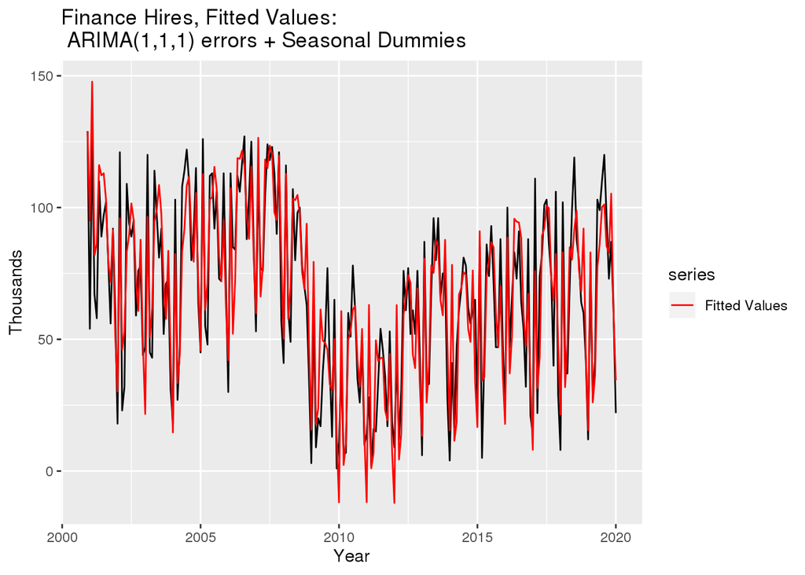

```r
autoplot(fh,main='Finance Hires, Fitted Values:\n ARIMA(1,1,1) errors + Seasonal Dummies')+
  autolayer(fh.tsc$fit,series='Fitted Values')+
  xlab('Year')+ylab('Thousands')+
  scale_color_manual(values=c('red'),
                     breaks=c('Fitted Values'))
```

The chosen model uses an $ARMA(1,1)$ to model the stochastic cycle. The $I(1)$ without drift indicates that no linear trend is visible in the data, and that the series is integrated. The seasonal variation is modeled with 11 seasonal dummies (December is omitted to avoid collinearity) as per the direction of this assignment.

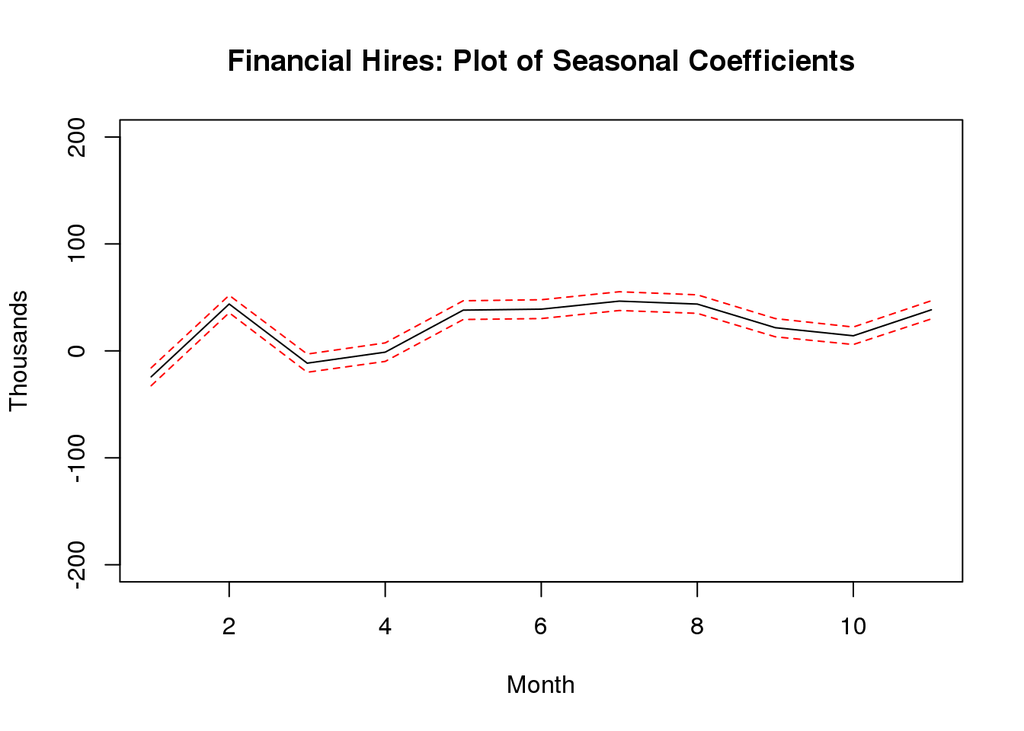

```r
seas.mid=fh.tsc$coef[3:13]
seas.err=(diag(fh.tsc$var.coef)**0.5)[3:13]
tcrit=2
seas.high=seas.mid+tcrit*seas.err
seas.low=seas.mid-tcrit*seas.err
plot(seas.mid,type='l',
     main='Financial Hires: Plot of Seasonal Coefficients',
     xlab='Month',ylab='Thousands',
     ylim=c(-200,200))
lines(seas.high,lty=2,col='red')
lines(seas.low,lty=2,col='red')
```

```r
rm(list=c('tcrit','seas.low','seas.mid','seas.high','seas.err'))
```

The confidence band is chosen for $t_{\mathrm{crit}}=2$. We see a hike up in hires in February, May through August, and November. THe hike up in summer reflects the influx of summer interns and other hiring programs.

**(c) Plot the respective residuals vs. fitted values and discuss your observations.**

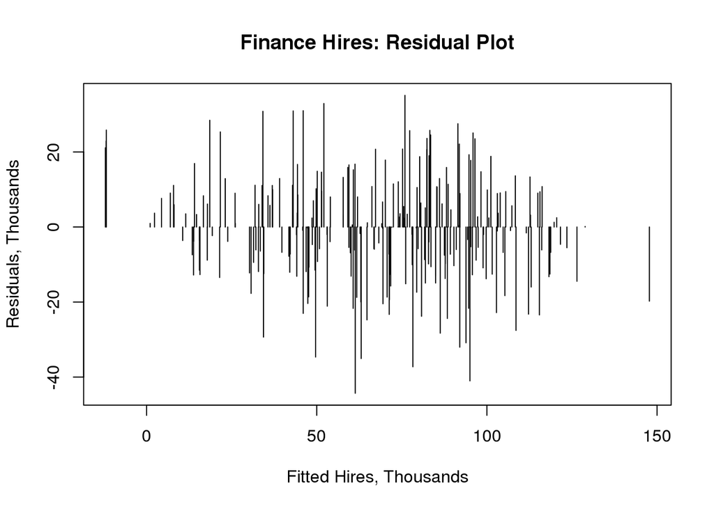

```r
plot(fh.tsc$fit,fh.tsc$res,type='h',
     main='Finance Hires: Residual Plot',xlab='Fitted Hires, Thousands',ylab='Residuals, Thousands')
```

The residuals seems to be heteroskedastic. Noteably, fitted values sometimes goes below 10, and have abnormally large residuals. This is because the arima model does not take into account the fact that hires needs to be a positive number.

The low variance at the high extreme of fitted values could be because of the saturation of available positions. At the low extreme, firms can not hire negative people, hence the variability in hires is capped.

**(e) Plot the ACF and PACF of the respective residuals and interpret the plots.**

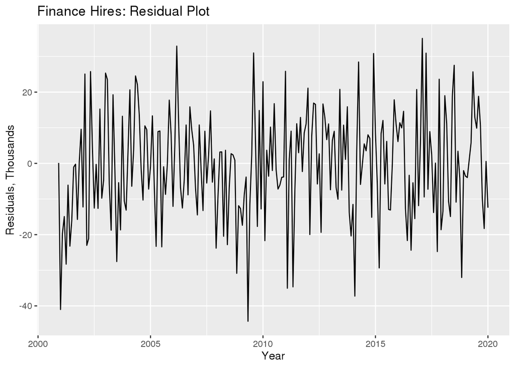

```r
autoplot(fh.tsc$res,
     main='Finance Hires: Residual Plot',xlab='Year',ylab='Residuals, Thousands')
```

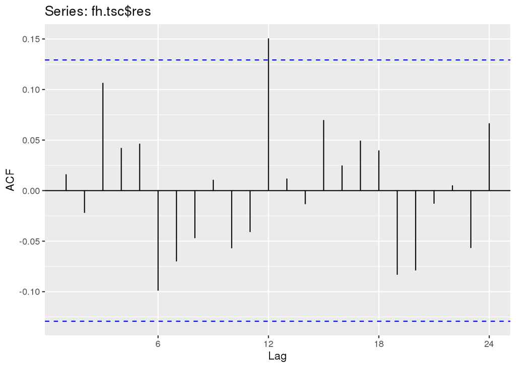

```r
ggAcf(fh.tsc$res)
```

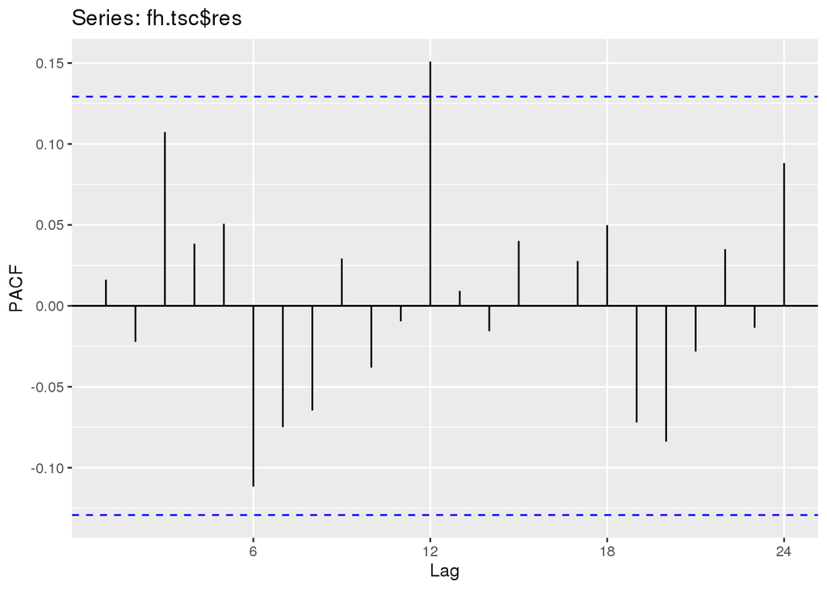

```r
ggPacf(fh.tsc$res)
```

In this residual plot, it seems there is still residual seasonality not accounted for by the seasonal dummies. In fact if we relax the restriction that we use seasonal dummies, auto.arima would choose to regress on stochastic seasonality. The reason we have residual seasonality left is because the seasonal dummies does not take into account the change in seasonality over the years.

**(f) Plot the respective CUSUM and interpret the plot.**

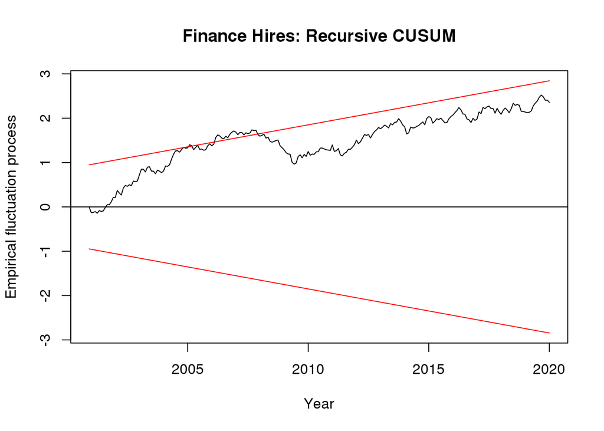

```r
plot(efp(fh.tsc$res~1, type = "Rec-CUSUM"),main='Finance Hires: Recursive CUSUM', xlab='Year')
```

**(g) Plot the respective Recursive Residuals and interpret the plot.**

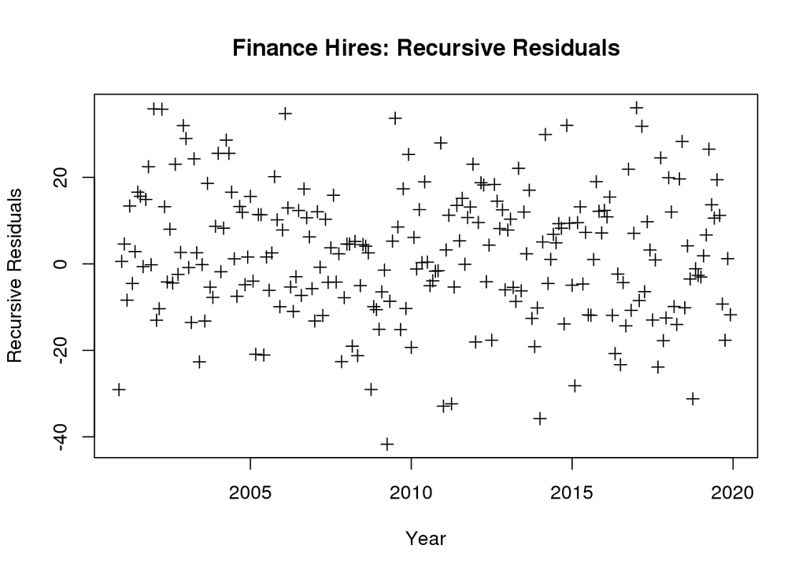

```r
plot(time(fh),recresid(fh.tsc$res~1)[1:230], pch=3,
     xlab="Year",ylab="Recursive Residuals",
     main='Finance Hires: Recursive Residuals')
```

The recursive residuals is evenly distributed in general, yet we see that their mean is biased downwards during the resession and upwards in the begining of the series. This echoes the signals we see in the CUSUM plot: the model breaks down in the early 2000s and during the recession.

**(h) For your model, discuss the associated diagnostic statistics.**

```r
accuracy(fh.tsc)
```

```
##                      ME    RMSE      MAE       MPE     MAPE      MASE
## Training set -0.6920531 15.1143 12.21112 -16.16076 38.84912 0.6832711
##                    ACF1
## Training set 0.01614959
```

**(i) Use your model to forecast 12-steps ahead. Your forecast should include the respective error bands.**

[figure not shown]

```r
newDummy=seasonaldummy(ts(seq(1:12),start=2020+2/12,freq=12))
plot(forecast(fh.tsc,h=12,xreg=newDummy),
     main='Finance Hires: Forecasts from ARIMA(2,1,2)+Seasonal Dummies',
     xlab='Year', ylab='Log Price')
```

**(j) Compare your forecast from (i) to the 12-steps ahead forecasts from ARIMA, Holt-Winters, and ETS models. Which model performs best in terms of MAPE?**

```r
fh.train=window(fh,end=c(2019,1))
fh.test=window(fh,start=c(2019,2))

fh.tsc=Arima(fh.train,order=c(1,1,1),xreg=seasonaldummy(fh.train))
fh.arima=auto.arima(fh.train)
fh.hw=HoltWinters(fh.train)
suppressWarnings(fh.ets<-ets(fh.train))
```

[figure not shown]

```r
# calculating fh forecasts under 4 models
fh.tsc.f=forecast(fh.tsc,h=12,xreg=seasonaldummy(fh.test))
fh.arima.f=forecast(fh.arima,h=12)
fh.hw.f=forecast(fh.hw,h=12)
fh.ets.f=forecast(fh.ets,h=12)
autoplot(fh.tsc.f,
     main='Finance Hires: Forecasts from ARIMA(2,1,2)+Seasonal Dummies',
     xlab='Year', ylab='Log Price')
```

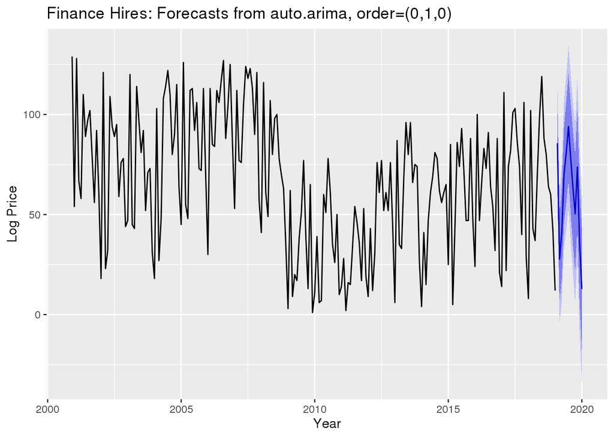

```r
autoplot(fh.arima.f,
     main='Finance Hires: Forecasts from auto.arima, order=(0,1,0)',
     xlab='Year', ylab='Log Price')
```

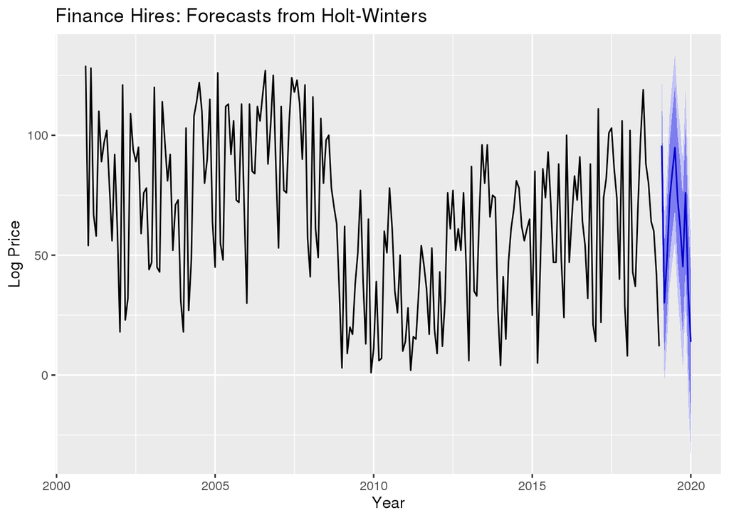

```r
autoplot(fh.hw.f,
     main='Finance Hires: Forecasts from Holt-Winters',
     xlab='Year', ylab='Log Price')
```

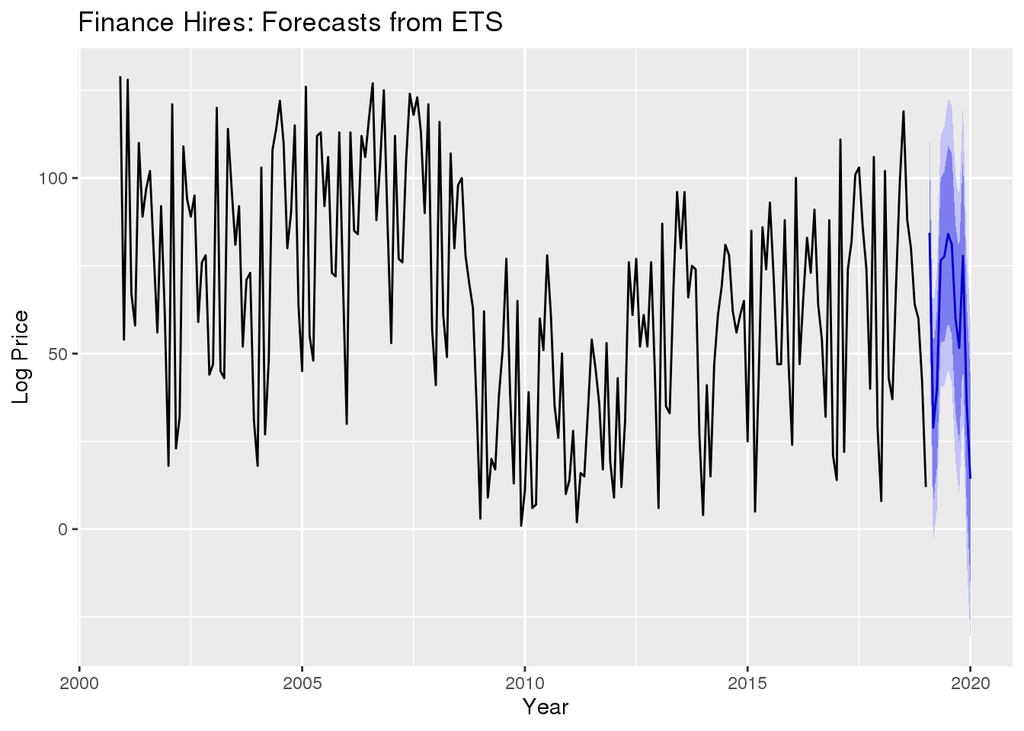

```r
autoplot(fh.ets.f,
     main='Finance Hires: Forecasts from ETS',
     xlab='Year', ylab='Log Price')
```

Using MAPE is rather unjustified in this ocassion, but it is nevertheless generated as follows.

```r
# Calculating MAPE
fh.tsc.MAPE=100*mean(abs(fh.tsc.f[4]$mean-fh.test)/fh.test)
fh.arima.MAPE=100*mean(abs(fh.arima.f[4]$mean-fh.test)/fh.test)
fh.hw.MAPE=100*mean(abs(fh.hw.f[4]$mean-fh.test)/fh.test)
fh.ets.MAPE=100*mean(abs(fh.ets.f[2]$mean-fh.test)/fh.test)
print(fh.tsc.MAPE)
```

```
## [1] 22.1688
```

```r
print(fh.arima.MAPE)
```

```
## [1] 22.93805
```

```r
print(fh.hw.MAPE)
```

```
## [1] 25.84444
```

```r
print(fh.ets.MAPE)
```

```
## [1] 22.90089
```

In terms of MAPE, our initial model in fact performs the best because it has the lowest MAPE.

**(k) Combine the four forecasts and comment on the MAPE from this forecasts vs., the individual ones.**

```r
# combining the forecasts
fh.combine.f=lm(fh.test~fh.tsc.f[4]$mean+fh.arima.f[4]$mean+fh.hw.f[4]$mean+fh.ets.f[2]$mean)$fit
fh.combine.MAPE=100*mean(abs(fh.combine.f-fh.test)/fh.test)
print(fh.combine.MAPE)
```

```
## [1] 9.787779
```

The combined model has a significantly lower MAPE than any of the four models by themselves.

**(l) Fit an appropriate VAR model using your two variables. Make sure to show the relevant plots and discuss your results from the fit.**

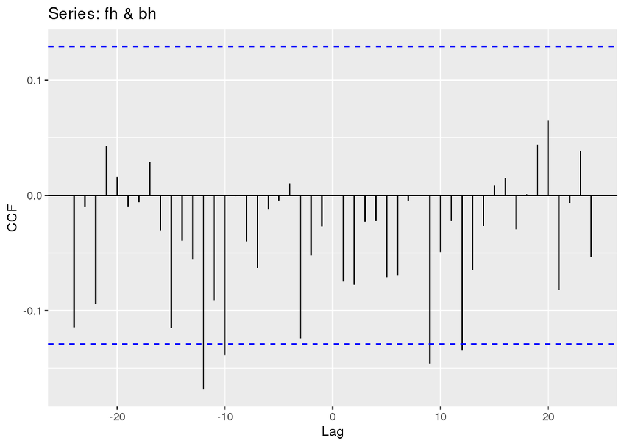

```r
ggCcf(fh,bh)
```

From the cross correlation coefficient plot, there are some peaks in at high lags, but the structure of those peaks does not conform to a simplistic statistical process. Let’s see what VARselect tells us to choose for the lag order.

```r
cbind(bh,fh) %>% data.frame -> bfh
VARselect(bfh, lag.max=10,type='const',season=12)$selection
```

```
## AIC(n)  HQ(n)  SC(n) FPE(n)
##      3      3      3      3
```

VARselects for order = 3. Now we fit a VAR(3) model with seasonal dummies

```r
bfh.var=VAR(bfh,p=3,type='const',season=12)
summary(bfh.var)
```

```
##
## VAR Estimation Results:
## =========================
## Endogenous variables: bh, fh
## Deterministic variables: const
## Sample size: 227
## Log Likelihood: -2153.424
## Roots of the characteristic polynomial:
## 0.9319 0.5623 0.5623 0.5477 0.3294 0.3294
## Call:
## VAR(y = bfh, p = 3, type = "const", season = 12L)
##
##
## Estimation results for equation bh:
## ===================================
## bh = bh.l1 + fh.l1 + bh.l2 + fh.l2 + bh.l3 + fh.l3 + const + sd1 + sd2 + sd3 + sd4 + sd5 + sd6 + sd7 + sd8 + sd9 + sd10 + sd11
##
##        Estimate Std. Error t value Pr(>|t|)
## bh.l1   0.08179    0.06946   1.178   0.2403
## fh.l1   0.28582    0.24307   1.176   0.2410
## bh.l2   0.16883    0.06872   2.457   0.0148 *
## fh.l2  -0.36832    0.24016  -1.534   0.1266
## bh.l3   0.06259    0.06929   0.903   0.3674
## fh.l3  -0.04041    0.23714  -0.170   0.8649
## const  76.43173   16.50935   4.630 6.43e-06 ***
## sd1   -29.32161   20.45202  -1.434   0.1532
## sd2     6.66483   20.50537   0.325   0.7455
## sd3   -14.88346   19.90681  -0.748   0.4555
## sd4   -21.03573   25.34656  -0.830   0.4075
## sd5    19.46637   25.61266   0.760   0.4481
## sd6   -49.33755   19.72857  -2.501   0.0132 *
## sd7   -40.23195   24.77278  -1.624   0.1059
## sd8   -11.81320   23.83472  -0.496   0.6207
## sd9   -11.96885   19.85541  -0.603   0.5473
## sd10  -23.96841   19.81655  -1.210   0.2278
## sd11  -15.34537   18.61697  -0.824   0.4107
## ---
## Signif. codes:  0 '***' 0.001 '**' 0.01 '*' 0.05 '.' 0.1 ' ' 1
##
##
```

[output cut: 32 more lines]

```
## Residual standard error: 15.11 on 209 degrees of freedom
## Multiple R-Squared:  0.81,   Adjusted R-squared: 0.7945
## F-statistic:  52.4 on 17 and 209 DF,  p-value: < 2.2e-16
##
##
##
## Covariance matrix of residuals:
##         bh     fh
## bh 3090.73  55.87
## fh   55.87 228.30
##
## Correlation matrix of residuals:
##         bh      fh
## bh 1.00000 0.06652
## fh 0.06652 1.00000
```

We have included the seasonal dummies because they are an important feature of the data. The fitted coefficients indicate that business hiring and finance hiring are not related to each other, as can be seen in the cross lag coefficients being non-significant. The only reason VARselect chose order=3 seems to be that finance hiring has some significant AR components.

**(m) Compute, plot, and interpret the respective impulse response functions.**

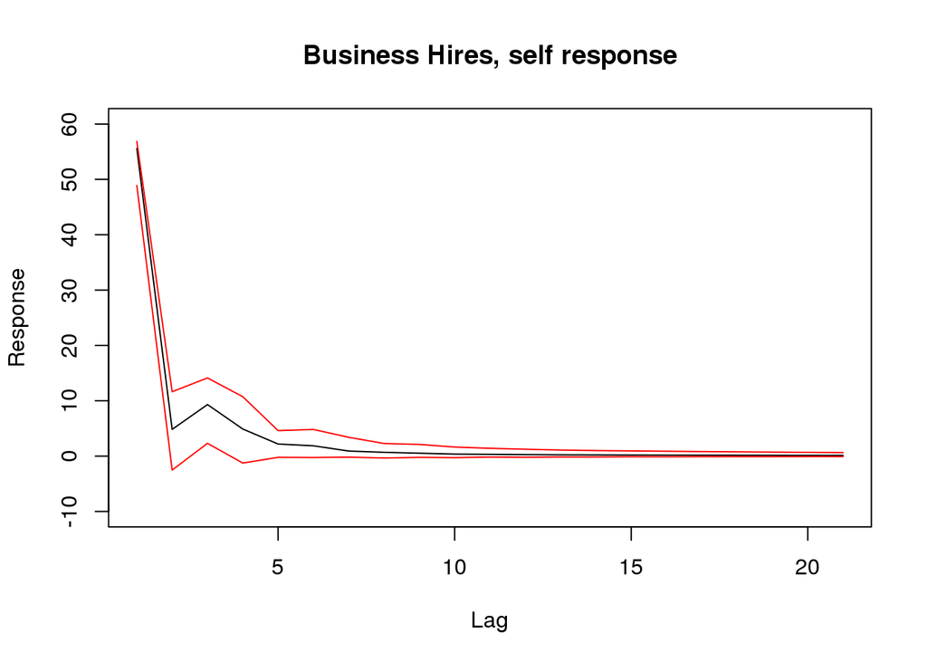

```r
bfh.var.irf=irf(bfh.var,n.ahead=20)

bfh.var.irf$irf$bh[,1] %>% plot(type='l',main='Business Hires, self response',ylim=c(-10,60),xlab='Lag',ylab='Response')
bfh.var.irf$Lower$bh[,1] %>% lines(type='l',col='red')
bfh.var.irf$Upper$bh[,1] %>% lines(type='l',col='red')
```

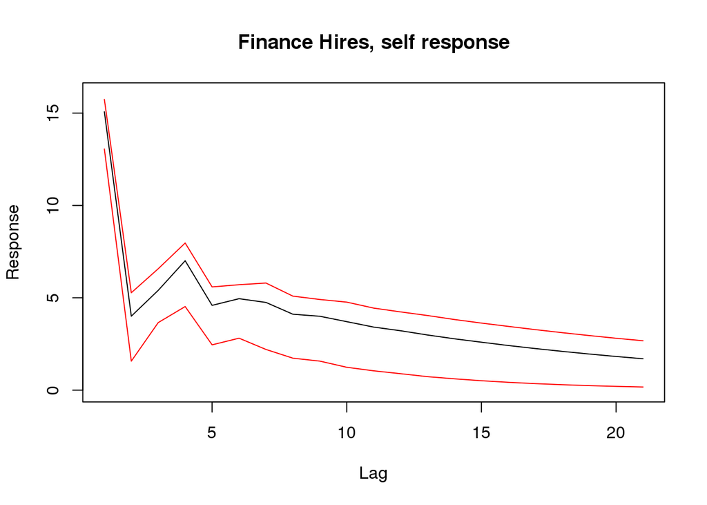

```r
bfh.var.irf$irf$fh[,2] %>% plot(type='l',main='Finance Hires, self response',ylim=c(0,16),xlab='Lag',ylab='Response')
bfh.var.irf$Lower$fh[,2] %>% lines(type='l',col='red')
bfh.var.irf$Upper$fh[,2] %>% lines(type='l',col='red')
```

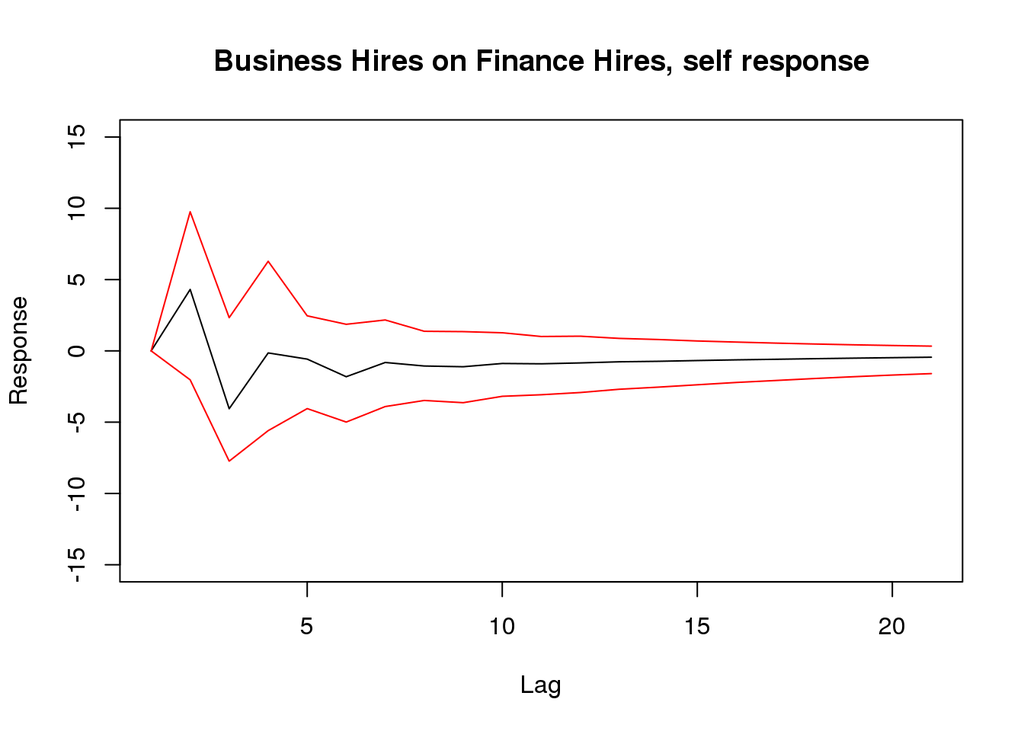

```r
bfh.var.irf$irf$fh[,1] %>% plot(type='l',main='Business Hires on Finance Hires, self response',ylim=c(-15,15),xlab='Lag',ylab='Response')
bfh.var.irf$Lower$fh[,1] %>% lines(type='l',col='red')
bfh.var.irf$Upper$fh[,1] %>% lines(type='l',col='red')
```

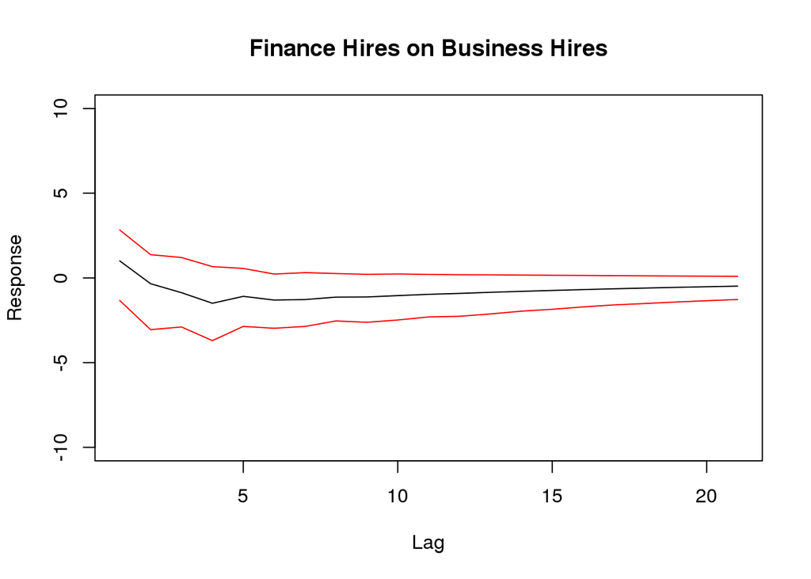

```r
bfh.var.irf$irf$bh[,2] %>% plot(type='l',main='Finance Hires on Business Hires',ylim=c(-10,10),xlab='Lag',ylab='Response')
bfh.var.irf$Lower$bh[,2] %>% lines(type='l',col='red')
bfh.var.irf$Upper$bh[,2] %>% lines(type='l',col='red')
```

We can see that both series have autoregressive behavior. Finance hires in particular has very strong persistence. However, the cross impulse response functions reflects that the series are not causally connected, as the significance band almost always covers the zero line.

**(n) Perform a Granger-Causality test on your variables and discuss your results from the test.**

```r
grangertest(bh ~ fh, order = 3)
```

|  | Res.Df | Df | F | Pr(>F) |
| --- | --- | --- | --- | --- |
| 1 | 220 | NA | NA | NA |
| 2 | 223 | -3 | 1.065464 | 0.3646118 |

```r
grangertest(fh ~ bh, order = 3)
```

|  | Res.Df | Df | F | Pr(>F) |
| --- | --- | --- | --- | --- |
| 1 | 220 | NA | NA | NA |
| 2 | 223 | -3 | 0.6606645 | 0.5770707 |

The granger causality tests indicates that neither series granger causes the other. This is expected since the VAR cross coefficients are not statistically significant.